# Sampling Distribution, Standard Errors

Shikhar Singh

August 31/September 9, 2026

# Agenda

### 1. Sampling Distribution

### 2. Standard Error

- Equation 3.4
- Properties of the standard error for the difference-in-means estimator

### 3. Estimating the Standard Error

- Equation 3.6

### 4. Adaptive Experimental Designs (Discussion)

# Sampling Distribution

The true ATE is a fixed, constant quantity. However, an *estimate* of the average treatment effect can vary with the random sample and random assignment ($d_i$).

> “A sampling distribution is the frequency distribution of a statistic obtained from hypothetical replications of a randomized experiment” (FEDAI:52)

For an **unbiased** estimator, the center of the sampling distribution is the true value of the parameter. As Gerber and Green note, “[a]ny single experiment might give a number that is too high or too low, but the expected value of this estimation procedure is the true ATE” (FEDAI: 54)

Say $\widehat{\theta}$ is a difference-in-means estimate, then the $\mathbb{E}[\widehat{\theta}] = \theta$ (where $\theta$ is the true value of the ATE).

To illustrate this, lets download a dataset (`w1_practice_data.csv`) and use a `for loop` to run simulations.

The steps here are:

1. Use randomizr to obtain an assignment vector, $d_i$
2. Use the switching equation to obtain the observed values of the outcome variable: $Y_i = d_i\cdot Y_i(1) + (1-d_i)\cdot Y_i(0)$.
3. Estimate the difference-in-means, i.e. the average value of the observed outcome in the treatment and control groups: $\widehat{\theta} = (\overline{Y_i | d_i=1}) - (\overline{Y_i | d_i=0})$.
4. Repeat this process a large number of times, drawing a new $d_i$ each time.
5. A histogram of the resulting estimates is the sampling distribution, and it should be centered on the true ATE.

```r
library(tidyverse)
library(knitr)
library(randomizr)

# Load the data set
dat <- read_csv("w1_practice_data.csv")

# True ATE
true_ate = dat %>% summarise(`True ATE` = mean(Y1-Y0))

kable(true_ate)
```

| True ATE |
| --- |
| 4.914945 |

```r
# Simulations using a for-loop

estimates <- c()

for(i in 1:10000){
  dat <- dat %>%
  mutate(
    d = complete_ra(N = nrow(dat), m = 500),
    Y = Y1*d + (1-d)*Y0
  )
  estimate = dat %>% summarise(DIM = mean(Y[d==1]) - mean(Y[d==0]))
  estimates = bind_rows(estimates, estimate)
}

# estimates contains the difference-in-means for the observed outcome in each iteration of the simulation.
# For DIM to be an unbiased estimator, mean(estimates) = true_ate

estimates %>% summarise(`Average Estimate` = mean(DIM)) %>% kable(.)
```

| Average Estimate |
| --- |
| 4.915409 |

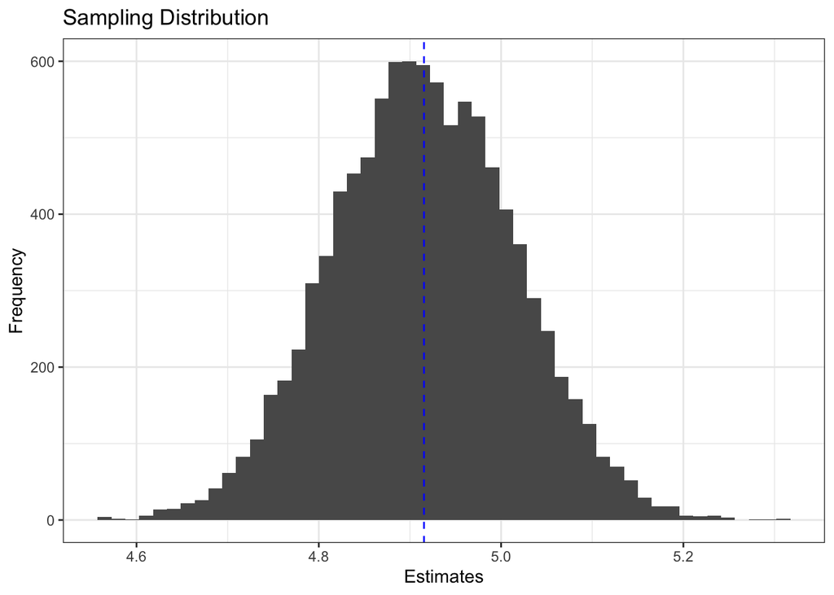

```r
# Lets visualize this using ggplot2

ggplot(estimates, aes(x = DIM)) + geom_histogram(bins = 50) +
  geom_vline(
  xintercept = mean(estimates$DIM),
  linetype = "dashed",
  color = "blue") +
  xlab("Estimates") +
  ylab("Frequency") +
  ggtitle("Sampling Distribution") +
  theme_bw()
```

**Notice:** The sampling distribution approximates a Normal distribution. According to the Central Limit Theorem, as the sample size $N \rightarrow \infty$, the sampling distribution approximates a Normal distribution.

# Standard Error

> The standard error is the standard deviation of the sampling distribution.

First, remember that the standard deviation of any random variable $X$ with $n$ observations is the square root of the average squared distance from the mean. That is, $\sqrt{(\frac{1}{n})\sum_{i=1}^n (X_i - \overline{X})^2}$

For the difference-in-means estimator then, let $\widehat{\theta_j}$ be the difference-in-means estimate for the $j$th experiment. Then,

> $\text{SE} = \sqrt{(\frac{1}{J})(\sum_1^J (\widehat{\theta_j} - \overline{\widehat{\theta_j}})^2}$ (where $\overline{\widehat{\theta_j}}$ is the mean of the sampling distribution, and there are $J$ possible random assignments).

**Notice:** For an unbiased estimator, $\overline{\widehat{\theta_j}}$ or the center of the sampling distribution is the true ATE.

> Mathematically, the *true* standard error equals: $\sqrt{\frac{1}{N-1}\{\frac{m}{N-m}Var[Y_i(0)] + \frac{N-m}{m}Var[Y_i(1)] + 2Cov[Y_i(0),Y_i(1)]\}}$

## Implications

There are important implications of Equation 3.4:

1. The larger the sample ($N$), the smaller the standard error.
2. The smaller the variance in $Y_i(1)$ or $Y_i(0)$, the smaller the standard error. Measurement error in the outcome *increases* the variance in potential outcomes and the standard error.
3. The smaller the covariance between potential outcomes, $Cov[Y_i(1),Y_i(0)]$, the smaller the standard error.

**Robinhood Treatments:** A special case emerges when $Y_i(1)$ and $Y_i(0)$ negatively covary. This happens when subjects with the lowest untreated potential outcomes have the highest treated outcomes; and those with the highest $Y_i(0)$’s have the lowest $Y_i(1)$’s.

To see this, lets rewrite $Y_i(1) = Y_i(0) + \tau_i$ (where $\tau_i$ is the individual-level treatment effect).

By implication, $Cov[Y_i(1),Y_i(0)] = Cov[Y_i(0) + \tau_i,Y_i(0)] = Var[Y_i(0)] + Cov[Y_i(0), \tau_i]$. Interventions where the covariance between the baseline outcome and treatment effect is 0 or negative will have smaller standard errors.

**Empirical Example:** Robin Hood Treatments and Sampling Variability

Consider two treatments, A and B, such that A has a constant effect on every subject ($Y_i(1) = Y_i(0) + 1$), and B is a robin hood treatment, i.e. it equalizes outcomes (those with low $Y_i(0)$’s move-up and those with high untreated potential outcomes move-down).

Data from Question 4, Chapter III

| Y0 | YA | YB |
| --- | --- | --- |
| 1 | 2 | 3 |
| 2 | 3 | 3 |
| 3 | 4 | 3 |
| 4 | 5 | 3 |
| 5 | 6 | 3 |

The key intuition here is that for treatment A $Y_i(0)$ and $Y_i(1)$ positively covary: some units have both high treated and untreated potential outcomes, while others have low $Y_i(0)$ and $Y_i(1)$ values. As a result, when a unit $i$ (say with high Y1 and Y0 values) moves between treatment conditions under different hypothetical assignments, $i$ considerably changes group means. That is to say, when $i$ is assigned to treatment, $i$ “pushes-up” the treatment group mean *and* “pushes-down” the control group mean. This produces a large ATE estimate. On the other hand, when $i$ is assigned to control, $i$ “pushes-up” the control group mean *and* “pushes-down” the treatment group mean. This produces a small ATE estimate. As we can see, this extreme flip-flop increases the sampling variability. Here is an illustration of the fact.

*Step 1:* Obtain all possible ways in which $m=2$ of $N=5$ subjects are assigned to treatment.

Permutation Matrix

| d1 | d2 | d3 | d4 | d5 | d6 | d7 | d8 | d9 | d10 |
| --- | --- | --- | --- | --- | --- | --- | --- | --- | --- |
| 0 | 0 | 0 | 0 | 0 | 0 | 1 | 1 | 1 | 1 |
| 0 | 0 | 0 | 1 | 1 | 1 | 0 | 0 | 0 | 1 |
| 0 | 1 | 1 | 0 | 0 | 1 | 0 | 0 | 1 | 0 |
| 1 | 0 | 1 | 0 | 1 | 0 | 0 | 1 | 0 | 0 |
| 1 | 1 | 0 | 1 | 0 | 0 | 1 | 0 | 0 | 0 |

*Step 2:* Estimate the difference in means for each assignment vector

Sampling Distribution of ATE

| Treatment Effect of A | Treatment Effect of B |
| --- | --- |
| 3.5000000 | 1.0000000 |
| 2.6666667 | 0.6666667 |
| 1.8333333 | 0.3333333 |
| 1.8333333 | 0.3333333 |
| 1.0000000 | 0.0000000 |
| 0.1666667 | -0.3333333 |
| 1.0000000 | 0.0000000 |
| 0.1666667 | -0.3333333 |
| -0.6666667 | -0.6666667 |
| -1.5000000 | -1.0000000 |

*Step 3:* Calculate the standard deviation of the sampling distribution (i.e. the standard error)

True SE of ATE

[output not shown]

> The true standard error of the average treatment effect is: $\sqrt{\frac{1}{N-1}\{\frac{m}{N-m}Var[Y_i(0)] + \frac{N-m}{m}Var[Y_i(1)] + 2Cov[Y_i(0),Y_i(1)]\}}$.

Treatment B produces a smaller standard error because:

1. Treatment B minimizes $Var[Y_i(1)]$ (variance in the treated potential outcomes) by reducing the achievement gap or heterogeneity in treated potential outcomes. In fact, $Var[Y_i(B)] = 0$ while $Var[Y_i(A)] = 2$.
2. Treatment B minimizes the covariance between treated and untreated potential outcomes. $Cov(Y_0, Y_A) = 2$ and $Cov(Y_0, Y_B) = 0$.

For this reason, a treatment that “bridges the gap” (i.e. it has a positive effect on subjects with low untreated potential outcomes and a negative effect on subjects with high untreated potential outcomes) will always have lower sampling variability.

4. Researchers should allocate more units to the experimental condition with higher variance in potential outcomes.

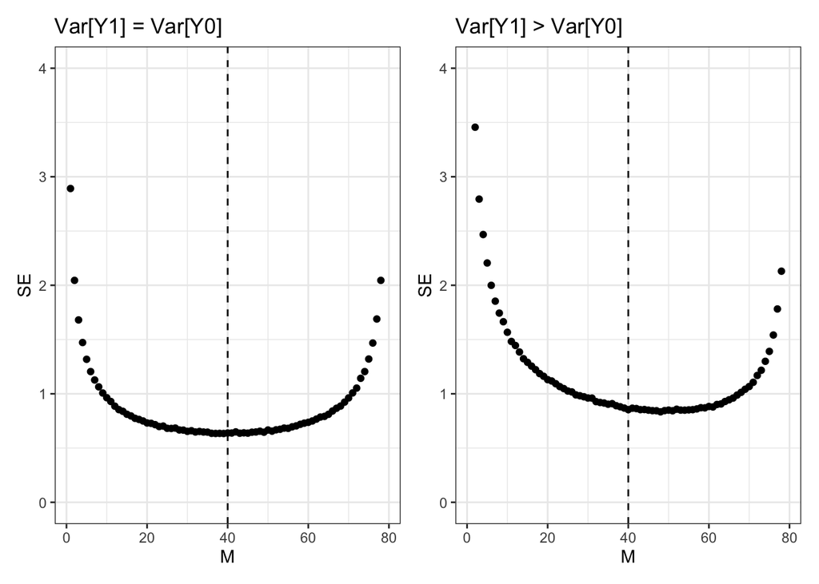

```r
library(tidyverse)

set.seed(2024) # for replicability

## Case 1: Create some data such that Var(Y1) = Var(Y0)

Y1 <- runif(80, min = 0, max = 10)
Y0 <- Y1 - 10 # A constant treatment effect gives us Var[Y1] = Var[Y0].

# A function called sims that calculates the standard error, given some data

sims <- function(N,m,Y1,Y0){
# Getting all possible assignment vectors when m of N are treated
declaration <- randomizr::declare_ra(N = N, m = m)
D <- randomizr::obtain_permutation_matrix(declaration)
# Defining the function dif_in_means
dif_in_means <- function(Y1,Y0,Z){
  # We need to ensure the dataset columns are numerical vectors, not characters
  as.num <- function(x) {as.numeric(as.character(x))}
  Y1 <- as.num(Y1)
  Y0 <- as.num(Y0)
  Z <- as.num(Z)
  #Switching equation
  Y <- Y1*Z + (1-Z)*Y0
  # ATE estimate
  estimate <- mean(Y[Z==1], na.rm = T) - mean(Y[Z==0], na.rm = T)
  return(estimate)
}
# Getting sampling distribution of ATE
reps <- dim(D)[2] # gives the number of columns in the permutation matrix D
ate <- rep(0,reps)
for(i in 1:reps){
  Z = D[,i]
  ate[i] <- dif_in_means(Y1,Y0, Z)
}
# Creating output vector
output <- tibble(
  M = m,
  SE = sd(ate)
)
return(output)
}

# Calculating the standard error for different m

output1 <- c()

for(i in 1:79){
  result <- sims(N=80,m=i,Y1,Y0)
  output1 = bind_rows(output1, result)
}


# Case 2:  Create some data such that Var(Y1) > Var(Y0)

Y0_new <- runif(80, min = 0, max = 10)
Y1_new <- Y0_new + (Y0_new/1.5) # A treatment effect that is positively correlated with Y0 gives us Var[Y1] > Var[Y0].

output2 <- c()
for(i in 1:79){
  result <- sims(N=80,m=i,Y1_new,Y0_new)
  output2 = bind_rows(output2, result)
}

# Comparing the two simulations

library(patchwork)

fig1 <- ggplot(data = output1, aes(x = M, y = SE)) +
  geom_point() +
  geom_vline(xintercept = 40, linetype = "dashed") +
    ylim(c(0,4)) +
  ggtitle("Var[Y1] = Var[Y0]") +
  theme_bw()

fig2 <- ggplot(data = output2, aes(x = M, y = SE)) +
  geom_point() +
  geom_vline(xintercept = 40, linetype = "dashed") +
  ylim(c(0,4)) +
  ggtitle("Var[Y1] > Var[Y0]") +
  theme_bw()


fig1 + fig2
```

When $Var[Y_i(1)] = Var[Y_i(0)]$, we observe the “tightest” sampling distribution (i.e. the lowest standard error) when $m \approx 40$. When $Var[Y_i(1)] > Var[Y_i(0)]$, the optimal design would have $m \approx 47$ subjects in treatment. To minimize the standard error, should allocate more units to the treatment condition.

# Estimating the SE

Since we do not observe both potential outcomes for any subject, we cannot calculate the true standard error using either the formula or simulations. Instead, we *estimate* the standard error using observed data.

> $\widehat{SE} = \sqrt{\frac{\widehat{Var(Y_i(0))}}{N-m} + \frac{\widehat{Var(Y_i(1))}}{m}}$ (Equation 3.6)

Where

$\widehat{Var(Y_i(1))} = \frac{1}{m\color{red}{-1}} \sum_1^m (Y_i|d_i=1 - \frac{\sum_1^m Y_i | d_i=1}{m})^2$

$\widehat{Var(Y_i(0))} = \frac{1}{N-m\color{red}{-1}} \sum_{m+1}^N (Y_i|d_i=0 - \frac{\sum_{m+1}^N Y_i | d_i=0}{N-m})^2$

**Note:** In Equation 3.4 we use $Var[\cdot]$ or $Cov[\cdot]$, while in Equation 3.6 we use $\widehat{Var[\cdot]}$ and $\widehat{Cov[\cdot]}$. This is a meaningful difference: $Var[\cdot]$ is the true variance of a potential outcome, $\widehat{Var[\cdot]}$ is an estimate of that variance using observed data. This means that *estimate* adjusts for degrees of freedom, i.e. divide by $m-1$, $N-m-1$ rather than $m$ or $N-m$. When you use `var`, `cov` and `sd` in R, they all adjust for degrees of freedom. So when you calculate the true SE using Equation 3.4 in R, make sure to not use the base functions but to write a custom function or apply the degrees of freedom correction to the base functions.

**Practice:** Download `w1_practice_data.csv` (used earlier in this class when introducing sampling distributions) and calculate the true standard error by applying the mathematical formula (equation 3.4) and conducting simulations using a for-loop. Your answers should tally.

# Solution to Practice

**Practice:** Download `w1_practice_data.csv` (used earlier in this class when introducing sampling distributions) and calculate the true standard error by applying the mathematical formula (equation 3.4) and conducting simulations using a for-loop. Your answers should tally.

```r
library(randomizr)

# Load the data set
dat <- read_csv("w1_practice_data.csv")

estimates <- c()

for(i in 1:50000){
  dat <- dat %>%
  mutate(
    d = complete_ra(N = nrow(dat), m = 500),
    Y = Y1*d + (1-d)*Y0
  )
  estimate = dat %>% summarise(DIM = mean(Y[d==1]) - mean(Y[d==0]))
  estimates = bind_rows(estimates, estimate)
}

# Write custom functions
# (This ensures you are calculating the true variance or covariance, not correcting for degrees of freedom)

var_pop <- function(x){sum((x-mean(x))^2)/(length(x))}
cov_pop <- function(x,y){sum((x-mean(x))*(y-mean(y)))/(length(x))}

# Simulation based calculation

out2 <- estimates %>% summarise(`SE with simulations` = sqrt(var_pop(DIM)))

# Formula-based calculation of SE

m <- 500
n = nrow(dat)-m

out1 <- dat %>% summarise(`SE using formula` = sqrt(1/((m+n)-1)*((m/n)*var_pop(dat$Y0) + (n/m)*var_pop(dat$Y1) + 2*cov_pop(dat$Y1,dat$Y0))))



output <- bind_cols(out1, out2)

kable(output,
      digits = 4,
      caption = "True SE: Formula v. Simulations",
      caption.above = TRUE)
```

True SE: Formula v. Simulations

| SE using formula | SE with simulations |
| --- | --- |
| 0.1002 | 0.1005 |